# Clinical utility of pre-extubation respiratory sampling

TIM POP study — ACCPM manuscript figures and tables

Author

Alexandre Sitbon

# Main manuscript

## Table 1 — Patient characteristics

Table 1. Demographic, clinical and surgical characteristics of the study cohort.

| Characteristic | Value |
| --- | --- |
| Age, years | 62.0 [53.0–70.0] (n=122) |
| BMI, kg/m² | 24.0 [20.0–29.8] (n=122) |
| SOFA score | 7.0 [4.0–10.0] (n=122) |
| SAPS II | 45.0 [35.0–59.0] (n=122) |
| Surgery duration, hours | 5.5 [4.0–7.0] (n=122) |
| Pre-extubation LUS | 10.0 [7.0–15.0] (n=81) |
| Male sex | 84/122 (68.9%) |
| Hypertension | 57/122 (46.7%) |
| Diabetes | 34/122 (27.9%) |
| COPD | 14/122 (11.5%) |
| Immunosuppression | 21/122 (17.2%) |
| Antibiotics within 90 days | 53/122 (43.4%) |
| Liver transplantation | 58/122 (47.5%) |
| Vascular surgery | 22/122 (18.0%) |

Download Table 1 (PDF) · CSV

Continuous variables: median [IQR]; categorical variables: n/N (%), with available-case denominators.

## Figure 1 — Clinical utility cascade

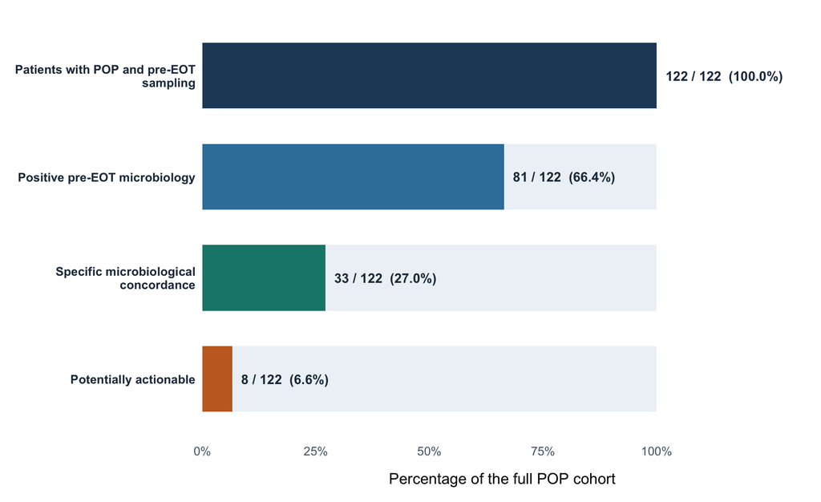

PDF vector · TIFF 600 dpi

**Figure 1.** Patient-level cascade; percentages use the full cohort denominator. Among 122 sampled POP cases, 81/122 (66.4%) had positive pre-extubation microbiology. Specific overlap was present in 33/81 (40.7%) positive samples. Specific overlap with inadequate empirical therapy was documented in 8/122 (6.6%) of the cohort. This is a candidate opportunity, not demonstrated preventability. Adequacy was missing in 2 specifically concordant cases.

## Table 2 — Microbiological findings

Table 2. Microbiological yield, concordance and observed candidate actionability.

| Characteristic | n/N (%) | 95% CI |
| --- | --- | --- |
| Pre-extubation respiratory sampling | 122/122 (100.0%) | 97.0–100.0% |
| Positive pre-extubation microbiology | 81/122 (66.4%) | 57.3–74.7% |
| Negative pre-extubation microbiology | 41/122 (33.6%) | 25.3–42.7% |
| Any microbiological concordance among positive samples | 54/81 (66.7%) | 55.3–76.8% |
| Specific concordance excluding oropharyngeal flora | 33/81 (40.7%) | 29.9–52.2% |
| Specific concordance in overall cohort | 33/122 (27.0%) | 19.4–35.8% |
| Potentially actionable in overall cohort | 8/122 (6.6%) | 2.9–12.5% |

Download Table 2 (PDF) · CSV

Exact binomial confidence intervals. Specific concordance excludes oropharyngeal flora from the intersection, not from the positive-sample denominator.

## Table 3 — Antimicrobial management

Table 3. Empirical antimicrobial adequacy, adaptation and resistance.

| Characteristic | Value |
| --- | --- |
| Adequate empirical therapy | 78/100 (78.0%) |
| Inadequate empirical therapy | 22/100 (22.0%) |
| Missing/non-evaluable adequacy | 22/122 (18.0%) |
| Adaptation at 48 h | 63/100 (63.0%) |
| Reported resistance | 32/110 (29.1%) |

| Pre-extubation culture | Inadequate therapy |
| --- | --- |
| Negative | 6/25 (24.0%) |
| Positive | 16/75 (21.3%) |

Download Table 3 (PDF) · CSV · Adequacy by positivity (PDF) · CSV

Empirical therapy was inadequate in 22/100 (22.0%) evaluable cases; adaptation was recorded in 63/100 (63.0%). Adaptation does not necessarily indicate de-escalation.

## Figure 2 — Resistance and empirical inadequacy

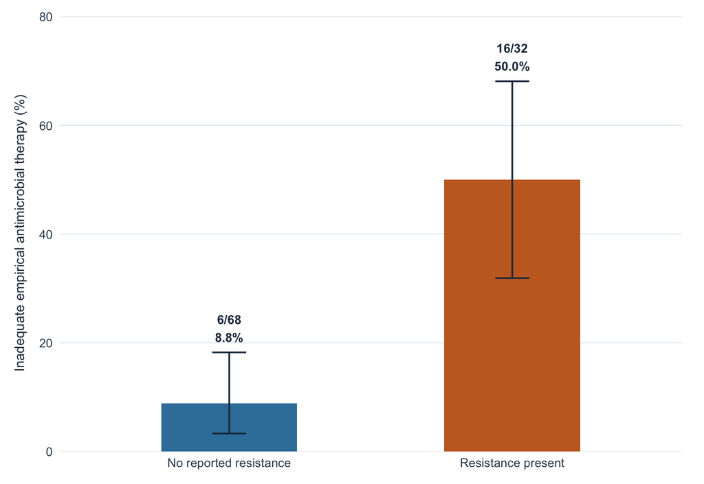

PDF vector · TIFF 600 dpi

**Figure 2.** Proportion of inadequate empirical therapy by recorded resistance status, with exact binomial 95% confidence intervals. Unadjusted Fisher exact OR 10.02 (95% CI 3.13–36.66; P = 9.83e-06). Resistance at POP diagnosis is not a prospective predictor.

# Supplementary material

## Figure S1 — Pre-extubation microbiology

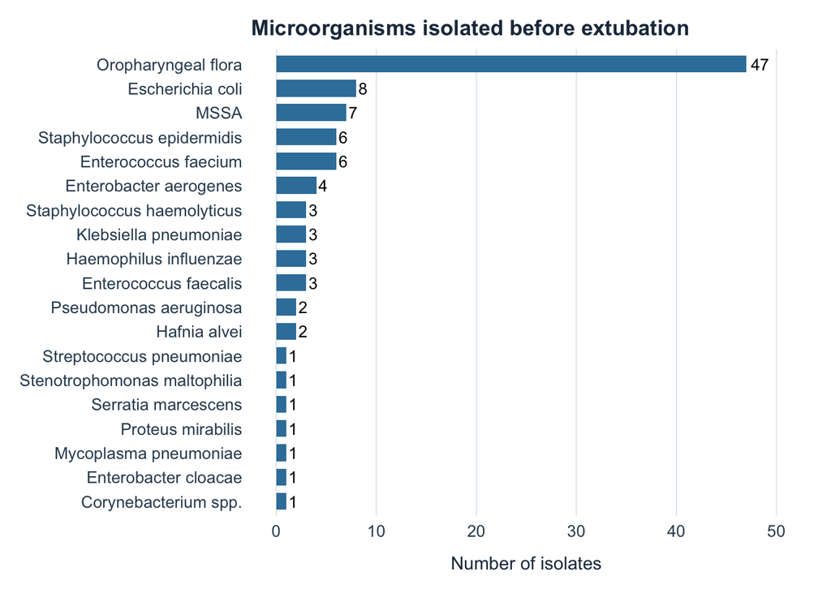

PDF · TIFF

**Figure S1.** Organism occurrences in pre-extubation samples. Polymicrobial samples may contribute multiple organisms; counts are not mutually exclusive patient proportions.

## Figure S2 — POP microbiology

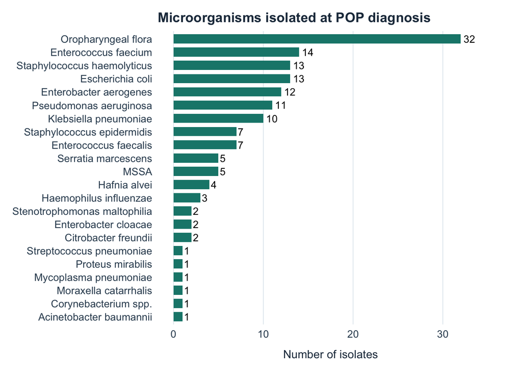

PDF · TIFF

**Figure S2.** Organism occurrences at POP diagnosis. Counts describe documented ecology, not organism-specific incidence.

## Figure S3 — Microbiological co-occurrences

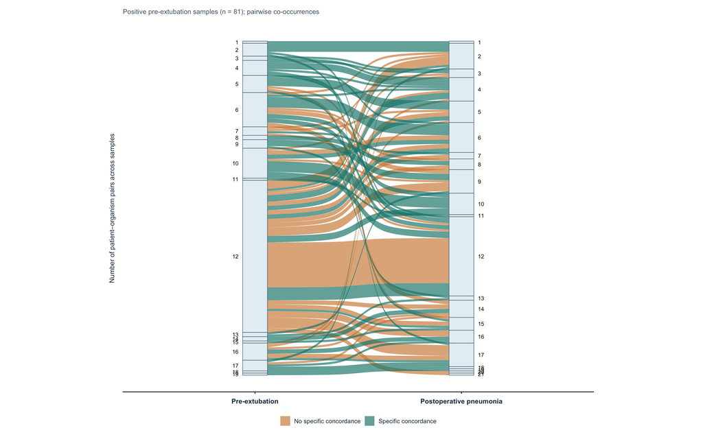

PDF · TIFF

**Figure S3.** Flows represent pairwise co-occurrences within patients with organisms at both time points, not proven organism transitions or unique patient counts. Polymicrobial samples contribute multiple pairs. Colour denotes patient-level specific overlap.

## Table S1 — Resistance phenotypes

Table S1. Recorded antimicrobial resistance phenotypes.

| resistance_status | n | percent |
| --- | --- | --- |
| Carbapenemase | 2 | 1.818182 |
| Cephalosporinase | 9 | 8.181818 |
| ESBL | 7 | 6.363636 |
| Highly resistant Pseudomonas | 4 | 3.636364 |
| Methicillin resistance | 10 | 9.090909 |
| No reported resistance | 78 | 70.909091 |

Table S1 (PDF) · CSV

Recorded phenotypes describe resistance at POP diagnosis; they do not establish prior susceptibility or availability to clinicians.

## Table S2 — Adaptation at 48 hours

Table S2a. Adaptation by pre-extubation positivity.

| preeot_positive | n | adapted | not_adapted | adapted_percent |
| --- | --- | --- | --- | --- |
| Negative | 25 | 13 | 12 | 52.00000 |
| Positive | 75 | 50 | 25 | 66.66667 |

Table S2b. Adaptation by specific concordance among positive samples.

| concordant_specific | n | adapted | not_adapted | adapted_percent |
| --- | --- | --- | --- | --- |
| No | 44 | 28 | 16 | 63.63636 |
| Yes | 31 | 22 | 9 | 70.96774 |

Table S2a (PDF) · CSV · Table S2b (PDF) · CSV

The tables describe recorded adaptation by pre-EOT positivity and specific concordance. They cannot establish that prior sampling caused a treatment change.

## Table S3 — Clinical outcomes (exploratory)

Table S3a. Clinical outcomes by empirical adequacy.

| empirical_therapy | n | ICU_LOS_median | ICU_LOS_Q1 | ICU_LOS_Q3 | Hospital_LOS_median | Hospital_LOS_Q1 | Hospital_LOS_Q3 | ICU_death | Hospital_death | POP_recurrence |
| --- | --- | --- | --- | --- | --- | --- | --- | --- | --- | --- |
| Adequate | 78 | 16.5 | 11 | 31.00 | 40.0 | 21.0 | 66.0 | 13 | 15 | 29 |
| Inadequate | 22 | 20.5 | 12 | 39.75 | 63.5 | 24.5 | 101.5 | 1 | 2 | 7 |

Table S3b. Exploratory unadjusted comparisons.

| Outcome | P_value |
| --- | --- |
| ICU length of stay | 0.364 |
| Hospital length of stay | 0.114 |
| ICU mortality | 0.294 |
| Hospital mortality | 0.348 |
| POP recurrence | 0.802 |

Table S3a (PDF) · CSV · Table S3b (PDF) · CSV

Unadjusted exploratory comparisons; no multiplicity correction. Event counts are not rates.

## Table S4 — Availability of analytical variables

Table S4. Missing or non-evaluable analytical variables in the full cohort.

| Variable | Missing n/N (%) |
| --- | --- |
| Empirical adequacy | 22/122 (18.0%) |
| Pre-EOT primary microbiology code | 0/122 (0.0%) |
| POP primary microbiology code | 0/122 (0.0%) |
| Sampling-to-POP delay | 0/122 (0.0%) |
| Resistance | 12/122 (9.8%) |
| 48-h adaptation | 22/122 (18.0%) |

Table S4 (PDF) · CSV

Empirical adequacy was unavailable for 22/122 (18.0%) patients. Blank entries and non-binary responses are treated as non-evaluable; the reasons require clinical review. Structural non-evaluability is not assumed to be random missingness.

## Table S5 — Characteristics by adequacy availability

Table S5. Available-case characteristics by availability of empirical adequacy.

| Variable | Evaluable | Non-evaluable | SMD |
| --- | --- | --- | --- |
| Age | 61.0 [52.8–70.0] (n=100) | 67.0 [55.8–73.5] (n=22) | -0.23 |
| SAPS II | 47.0 [35.0–59.5] (n=100) | 39.5 [34.2–49.2] (n=22) | 0.16 |
| SOFA | 8.0 [4.0–11.0] (n=100) | 5.5 [2.0–7.0] (n=22) | 0.36 |
| Liver transplantation | 47/100 (47.0%) | 11/22 (50.0%) | -0.06 |
| Prior antibiotics (90 days) | 48/100 (48.0%) | 5/22 (22.7%) | 0.54 |
| Positive pre-EOT | 75/100 (75.0%) | 6/22 (27.3%) | 1.07 |
| Specific overlap | 31/100 (31.0%) | 2/22 (9.1%) | 0.56 |
| Delay, days | 3.0 [2.0–5.0] (n=100) | 3.0 [2.0–4.0] (n=22) | 0.09 |
| Resistance | 32/100 (32.0%) | 0/10 (0.0%) | 0.97 |
| ICU death | 14/100 (14.0%) | 1/22 (4.5%) | 0.33 |

Table S5 (PDF) · CSV

Values are median [IQR] or n/N (%). SMD is the signed standardized mean difference (evaluable minus non-evaluable), using the pooled within-group variance. Differences may indicate selection into the evaluable subset; they do not establish the missingness mechanism.

## Table S6 — Sensitivity of candidate actionability

Table S6. Observed candidate proportion and extreme assumptions for unknown composite outcomes.

| Scenario | k | N | Estimate |
| --- | --- | --- | --- |
| Observed candidate proportion | 8 | 122 | 8/122 (6.6%) |
| Evaluable composite only | 8 | 120 | 8/120 (6.7%) |
| All unknown composite outcomes negative | 8 | 122 | 8/122 (6.6%) |
| All unknown composite outcomes positive | 10 | 122 | 10/122 (8.2%) |

Table S6 (PDF) · CSV

The composite is specific overlap plus inadequate empirical therapy. It is unknown in 2 patients; absence of overlap makes the composite negative even when adequacy is unavailable. Extreme scenarios bound the composite under the recorded microbiology, not the true clinical benefit. Result availability, susceptibility and coverage of the matching organism require chart adjudication.

## Table S7 — Alternative concordance definitions

Table S7. Patient-level concordance under alternative organism-set definitions; exact binomial 95% confidence intervals.

| Definition | k | N | Estimate [95% CI] |
| --- | --- | --- | --- |
| Any overlap, flora included (original) | 54 | 81 | 54/81 (66.7%) [55.3–76.8%] |
| Specific overlap (original) | 33 | 81 | 33/81 (40.7%) [29.9–52.2%] |
| Specific overlap, specific pre-EOT positive | 33 | 46 | 33/46 (71.7%) [56.5–84.0%] |
| Identical nonempty specific sets | 31 | 81 | 31/81 (38.3%) [27.7–49.7%] |
| All specific POP organisms present pre-EOT | 31 | 81 | 31/81 (38.3%) [27.7–49.7%] |
| All specific POP organisms present, specific POP positive | 31 | 63 | 31/63 (49.2%) [36.4–62.1%] |

Table S7 (PDF) · CSV

The main definition requires at least one shared specific organism. More stringent definitions distinguish identical nonempty profiles from coverage of all documented specific POP organisms. Empty profiles never count as matches. These are species-level comparisons, not evidence of strain identity or antibiotic susceptibility.

## Figure S4 — Concordance expected under random pairing

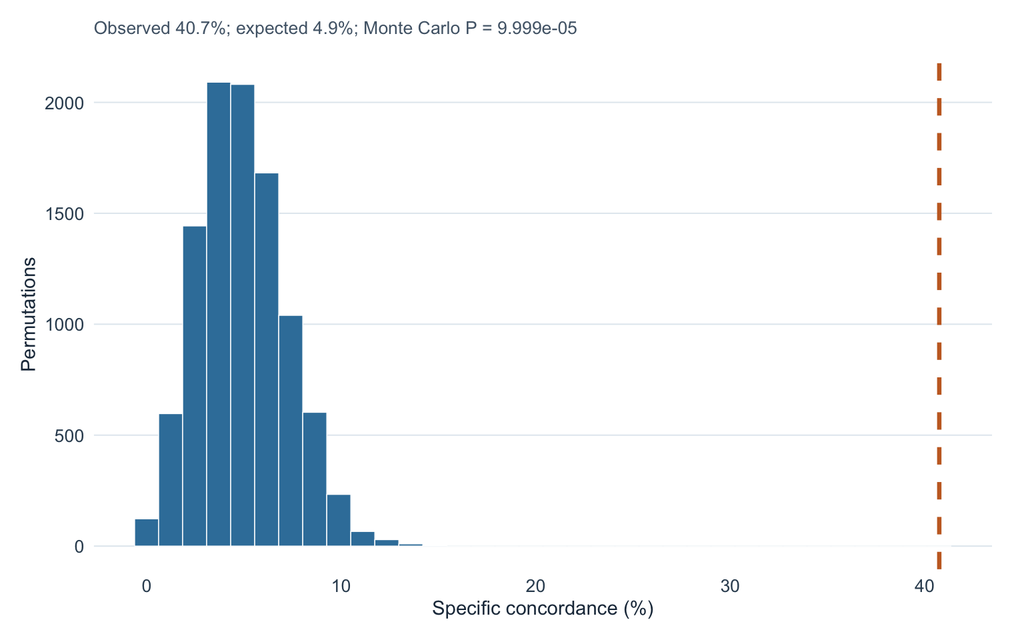

**Figure S4.** Distribution of specific concordance after 10,000 permutations of complete POP organism profiles among positive pre-EOT patients with known primary microbiology codes. The vertical line denotes observed concordance. Observed concordance was 33/81 (40.7%), compared with a mean of 4.9% under random pairing (one-sided Monte Carlo P = 1e-04). Exchangeability is assumed; shared surgery type, antibiotic exposure or calendar-period ecology may explain part of the association. This is exploratory and does not prove bacterial persistence.

PDF · TIFF

## Table S8 — Concordance by sampling-to-POP interval

Table S8. Specific overlap by calendar-day interval from pre-extubation sampling to POP diagnosis.

| window | k | N | Estimate [95% CI] |
| --- | --- | --- | --- |
| 0–2 days | 14 | 30 | 14/30 (46.7%) [28.3–65.7%] |
| 3–5 days | 18 | 40 | 18/40 (45.0%) [29.3–61.5%] |
| >5 days | 1 | 11 | 1/11 (9.1%) [0.2–41.3%] |

Table S8 (PDF) · CSV

The categories follow the initial manuscript and are descriptive. 0 positive-sample patients were excluded from this temporal analysis because of missing or negative intervals. This interval is not necessarily the interval from extubation to POP.

## Figure S5 — Temporal association with specific concordance

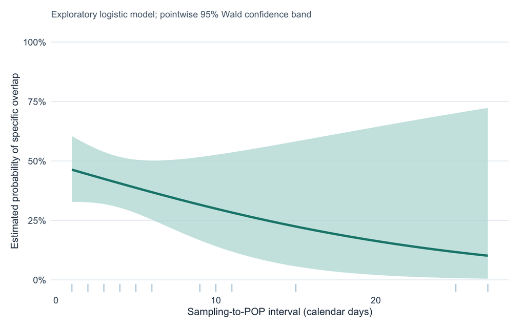

**Figure S5.** Estimated probability of specific overlap according to sampling-to-POP interval. Shading denotes pointwise 95% Wald confidence intervals; rug marks show observed intervals. The exploratory unadjusted logistic model estimated an OR per additional calendar day of 0.92 (95% CI 0.81–1.06; P = 0.25). The model assumes linearity on the log-odds scale; no optimal threshold or validated predictive performance is claimed.

PDF · TIFF

## Table S9 — Sensitivity by surgery and sampling technique

Table S9. Descriptive microbiological and therapeutic findings by surgical and sampling strata; exact binomial 95% confidence intervals.

| Stratum | Group | N | Yield | Specific overlap among positives | Inadequacy | Observed candidates | unknown |
| --- | --- | --- | --- | --- | --- | --- | --- |
| surgery | Liver transplantation | 58 | 36/58 (62.1%) [48.4–74.5%] | 13/36 (36.1%) [20.8–53.8%] | 10/47 (21.3%) [10.7–35.7%] | 3/58 (5.2%) [1.1–14.4%] | 1 |
| surgery | Other surgery | 64 | 45/64 (70.3%) [57.6–81.1%] | 20/45 (44.4%) [29.6–60.0%] | 12/53 (22.6%) [12.3–36.2%] | 5/64 (7.8%) [2.6–17.3%] | 1 |
| sampling | BAL | 49 | 37/49 (75.5%) [61.1–86.7%] | 21/37 (56.8%) [39.5–72.9%] | 9/43 (20.9%) [10.0–36.0%] | 5/49 (10.2%) [3.4–22.2%] | 0 |
| sampling | Protected distal sampling | 55 | 34/55 (61.8%) [47.7–74.6%] | 9/34 (26.5%) [12.9–44.4%] | 8/43 (18.6%) [8.4–33.4%] | 1/55 (1.8%) [0.0–9.7%] | 2 |
| sampling | Tracheal aspiration | 18 | 10/18 (55.6%) [30.8–78.5%] | 3/10 (30.0%) [6.7–65.2%] | 5/14 (35.7%) [12.8–64.9%] | 2/18 (11.1%) [1.4–34.7%] | 0 |

Table S9 (PDF) · CSV

Denominators differ by endpoint: all patients for yield and observed candidates, positive samples for specific overlap, evaluable adequacy for inadequacy. The unknown column counts non-evaluable composite outcomes. No interaction tests are performed because of sparse strata; these comparisons are not adjusted for case mix.

## Table S10 — Exploratory multivariable analysis

Table S10. Firth penalised logistic regression for empirical antimicrobial inadequacy; adjusted odds ratios and profile penalised likelihood 95% confidence intervals.

| Covariate | Adjusted OR | 95% CI lower | 95% CI upper | P value |
| --- | --- | --- | --- | --- |
| Reported resistance at POP diagnosis | 9.330 | 3.320 | 29.40 | 1.41e-05 |
| Antibiotics within 90 days before surgery | 0.890 | 0.256 | 3.02 | 8.51e-01 |
| Liver transplantation | 0.974 | 0.291 | 3.21 | 9.65e-01 |

Table S10 (PDF) · CSV

The complete-case model included 100 patients and 22 inadequacy events. Covariates were selected on clinical grounds for this exploratory reanalysis: reported resistance, antibiotic exposure within 90 days before surgery and liver transplantation. The adjusted OR for resistance was 9.33 (95% CI 3.32–29.40). Penalisation reduces small-sample bias but does not eliminate imprecision, residual confounding or selection bias. Resistance at POP diagnosis is partly linked to the definition of adequacy; this is neither a causal model nor a prospective prediction model.

## Clinical adjudication required before submission

The 8 observed candidate cases require review of microbiological result release time, susceptibility availability, whether the shared organism was uncovered by initial therapy, and whether a feasible alternative regimen would cover all relevant pathogens. These items cannot be inferred from sampling dates or species codes. Record them in a secure clinical workspace, not the public HTML. Report aggregate adjudication results only after verification.

## Statistical interpretation and limitations

All additional analyses are exploratory and were developed after inspection of the original results. No multiplicity-adjusted confirmatory claims are made. This retrospective cohort contains only sampled patients who developed POP; it cannot estimate POP incidence, diagnostic performance for incident POP, or the causal benefit of routine sampling. The resistance association is unadjusted and partly reflects the definition of adequacy. A parsimonious exploratory Firth model is reported in Table S10; the small event count limits precision and adjustment for additional covariates. No post-hoc power calculation is used.

# Technical audit

| Parameter | Value |
| --- | --- |
| Number of observations | 122 |
| Number of variables | 117 |
| Unique patient identifiers | 122 |
| Duplicated patient identifiers | 0 |

| Metric | n |
| --- | --- |
| Total cohort | 122 |
| Pre-EOT sampled | 122 |
| Pre-EOT positive | 81 |
| Pre-EOT negative | 41 |
| Broad concordance | 54 |
| Specific concordance | 33 |
| Adequacy evaluable | 100 |
| Adequate empirical therapy | 78 |
| Inadequate empirical therapy | 22 |
| Potentially actionable | 8 |

Patient-level records and dates are deliberately not displayed or exported. Screening and exclusion counts must be reconciled before creating a recruitment flowchart.